# NLP2_Project_Ashok

### **Natural Language Processing Project 2 - Ashok Shanmuga Sundaram**

## **PART-1 - Objective:**

The objective is to build a sequential NLP classifier that analyses the customer's sentiments based on their movie reviews in the IMDB database

### **1.0 Importing the Libraries**

```python
%tensorflow_version 2.x
import tensorflow as tf
tf.__version__
```

```
'2.4.1'
```

```python
# Initialize the random number generator
import random
import numpy as np
random_state = 42
np.random.seed(random_state)
tf.random.set_seed(random_state)

# Ignore the warnings
import warnings
warnings.filterwarnings("ignore")
```

```python
import pandas as pd
import tensorflow as tf

from itertools import islice

# Keras
from keras.layers import Dense, Embedding, LSTM, Dropout, MaxPooling1D, Conv1D, Input, Activation, Flatten, Bidirectional, GlobalMaxPool1D
from keras.preprocessing.sequence import pad_sequences
from keras.models import Model, Sequential
from keras.preprocessing import sequence
from keras.preprocessing.text import Tokenizer
from keras.datasets import imdb

from keras.callbacks import ModelCheckpoint, EarlyStopping

from sklearn.model_selection import train_test_split
from sklearn.metrics import classification_report
```

```python
from google.colab import drive
```

```python
drive.mount('/content/drive/')
```

```python
# Adding path to the folder where dataset file is located
project_path = '/content/drive/My Drive/AIML/Projects/NLP2/'

# Setting the current working directory
import os
os.chdir('/content/drive/My Drive/AIML/Projects/NLP2')
```

### **1.1. Importing IMDB data set**

- Loading IMDB dataset
- Spliting Data into Train and Test sets
- Taking 10,000 most frequent words

```python
vocab_size = 10000
maxlen = 300
(x_train, y_train), (x_test, y_test) = imdb.load_data(num_words = vocab_size)
```

### **1.2. Performing relevant sequence adding on the data and spliting the data into train and test sets**

```python
x_train = pad_sequences(x_train, maxlen = maxlen, padding = 'pre')
x_test =  pad_sequences(x_test, maxlen = maxlen, padding = 'pre')

X = np.concatenate((x_train, x_test), axis = 0)
y = np.concatenate((y_train, y_test), axis = 0)

x_train, x_test, y_train, y_test = train_test_split(X, y, test_size = 0.2, random_state = random_state, shuffle = True)
x_train, x_valid, y_train, y_valid = train_test_split(x_train, y_train, test_size = 0.2, random_state = random_state, shuffle = True)
```

### **1.3. Performing following data analysis:**

- Print shape of features and labels
- Print value of any one feature and it's label

```python
print('---'*20, f'\nNumber of rows in training dataset: {x_train.shape[0]}')
print(f'Number of columns in training dataset: {x_train.shape[1]}')
print(f'Number of unique words in training dataset: {len(np.unique(np.hstack(x_train)))}')


print('---'*20, f'\nNumber of rows in validation dataset: {x_valid.shape[0]}')
print(f'Number of columns in validation dataset: {x_valid.shape[1]}')
print(f'Number of unique words in validation dataset: {len(np.unique(np.hstack(x_valid)))}')


print('---'*20, f'\nNumber of rows in test dataset: {x_test.shape[0]}')
print(f'Number of columns in test dataset: {x_test.shape[1]}')
print(f'Number of unique words in test dataset: {len(np.unique(np.hstack(x_test)))}')


print('---'*20, f'\nUnique Categories: {np.unique(y_train), np.unique(y_valid), np.unique(y_test)}')

print('---'*20, f'\nPrinting value of a feature')
print(x_train[0])
print('---'*20, f'\nPrinting corresponding label')
print(y_train[0])
```

```
------------------------------------------------------------
Number of rows in training dataset: 32000
Number of columns in training dataset: 300
Number of unique words in training dataset: 9999
------------------------------------------------------------
Number of rows in validation dataset: 8000
Number of columns in validation dataset: 300
Number of unique words in validation dataset: 9984
------------------------------------------------------------
Number of rows in test dataset: 10000
Number of columns in test dataset: 300
Number of unique words in test dataset: 9995
------------------------------------------------------------
Unique Categories: (array([0, 1]), array([0, 1]), array([0, 1]))
------------------------------------------------------------
Printing value of a feature
[   0    0    0    0    0    0    0    0    0    0    0    0    0    0
    0    0    0    0    0    0    0    0    0    0    0    0    0    0
    0    0    0    0    0    0    0    0    0    0    0    0    0    0
    0    0    0    0    0    0    0    0    0    0    0    0    0    0
    0    0    0    0    0    0    0    0    0    0    0    0    0    0
    0    1    4   64  614   96    8  358   14  509    9    8 4040  129
  419  429    4 1513 1741   49 6177    2    7    4 1224  387    6  762
    7  129 1224 7851  783    5  280   25   26 8394 2985 3000  382   95
   25  238  358   14   22   10   10    4   64 1907 1698   16    4   65
  200    2    5 6958 7767   16  321   11    4  217    7    4 7212 2658
    5   38   16    4 8145  250  382   48   36   62   28 1075    4  226
   20   23   68    2   11 2853    5   89   36  853  809   11  119   62
   28   93   12    6   76   53  737   22   10   10    4   64  282   13
  520   12    6  342  675    9   88    7    2    5   27 1256   17   35
  284   54   12  266    8  212   10   10    2    2    5 6301 4029   71
 1053 9056  935    4  136   33    2    7    4  796 3617   16   43   99
   76    8    2  112   35 1966    2   11    4 1208  790 1502  182 6301
 4029   62   28  188  309  324   76  159   29   60 3820    4 1749 3026
    8    2   27  283  119   21   95  174    4  213    7    4   20   16
    8 8861 2091 8730 5681    5 1402   35 8585   23    4  393    7    4
  831  311   10   10  106   12   33  129  205 7623   33  222   13  124
   13   28   77    2   18  113]
------------------------------------------------------------
Printing corresponding label
0
```

### **1.4 Decoding the feature value to get original sentence**

```python
def decode_review(x, y):
  w2i = imdb.get_word_index()
  w2i = {k:(v + 3) for k, v in w2i.items()}
  w2i['<PAD>'] = 0
  w2i['<START>'] = 1
  w2i['<UNK>'] = 2
  i2w = {i: w for w, i in w2i.items()}

  ws = (' '.join(i2w[i] for i in x))
  print(f'Review: {ws}')
  print(f'Actual Sentiment: {y}')
  return w2i, i2w

w2i, i2w = decode_review(x_train[0], y_train[0])

# get first 50 key, value pairs from id to word dictionary
print('---'*30, '\n', list(islice(i2w.items(), 0, 50)))
```

```
Downloading data from https://storage.googleapis.com/tensorflow/tf-keras-datasets/imdb_word_index.json
Review: <PAD> <PAD> <PAD> <PAD> <PAD> <PAD> <PAD> <PAD> <PAD> <PAD> <PAD> <PAD> <PAD> <PAD> <PAD> <PAD> <PAD> <PAD> <PAD> <PAD> <PAD> <PAD> <PAD> <PAD> <PAD> <PAD> <PAD> <PAD> <PAD> <PAD> <PAD> <PAD> <PAD> <PAD> <PAD> <PAD> <PAD> <PAD> <PAD> <PAD> <PAD> <PAD> <PAD> <PAD> <PAD> <PAD> <PAD> <PAD> <PAD…
Actual Sentiment: 0
------------------------------------------------------------------------------------------
 [(34704, 'fawn'), (52009, 'tsukino'), (52010, 'nunnery'), (16819, 'sonja'), (63954, 'vani'), (1411, 'woods'), (16118, 'spiders'), (2348, 'hanging'), (2292, 'woody'), (52011, 'trawling'), (52012, "hold's"), (11310, 'comically'), (40833, 'localized'), (30571, 'disobeying'), (52013, "'royale"), (40834…
```

### **1.5 Design, train, tune and test a sequential model (Keras Embedding Layer Model**

Embedding layer is like a dicionary that maps a index assigned to a word to a word vector. This layer is very flexible and can be used as below:

1. The embedding layer can be used at the start of a larger deep learning model.
2. Pre-trained word embeddings can be loaded into the embedding layer when model is created.
3. The embedding layer can be used to train word2vec models.
4. The keras embedding layer doesn't require onehot encoding of words

```python
# Model
model = Sequential()
model.add(Embedding(vocab_size, 256, input_length = maxlen))
model.add(Dropout(0.25))
model.add(Conv1D(256, 5, padding = 'same', activation = 'relu', strides = 1))
model.add(Conv1D(128, 5, padding = 'same', activation = 'relu', strides = 1))
model.add(MaxPooling1D(pool_size = 2))
model.add(Conv1D(64, 5, padding = 'same', activation = 'relu', strides = 1))
model.add(MaxPooling1D(pool_size = 2))
model.add(LSTM(75))
model.add(Dense(1, activation = 'sigmoid'))
model.compile(loss = 'binary_crossentropy', optimizer = 'adam', metrics = ['accuracy'])
print(model.summary())

# Adding callbacks
es = EarlyStopping(monitor = 'val_loss', mode = 'min', verbose = 1, patience = 0)
mc = ModelCheckpoint('imdb_model.h5', monitor = 'val_loss', mode = 'min', save_best_only = True, verbose = 1)
```

```
Model: "sequential"
_________________________________________________________________
Layer (type)                 Output Shape              Param #
=================================================================
embedding (Embedding)        (None, 300, 256)          2560000
_________________________________________________________________
dropout (Dropout)            (None, 300, 256)          0
_________________________________________________________________
conv1d (Conv1D)              (None, 300, 256)          327936
_________________________________________________________________
conv1d_1 (Conv1D)            (None, 300, 128)          163968
_________________________________________________________________
max_pooling1d (MaxPooling1D) (None, 150, 128)          0
_________________________________________________________________
conv1d_2 (Conv1D)            (None, 150, 64)           41024
_________________________________________________________________
max_pooling1d_1 (MaxPooling1 (None, 75, 64)            0
_________________________________________________________________
lstm (LSTM)                  (None, 75)                42000
_________________________________________________________________
dense (Dense)                (None, 1)                 76
=================================================================
Total params: 3,135,004
Trainable params: 3,135,004
Non-trainable params: 0
_________________________________________________________________
None
```

```python
# Fit the model
model.fit(x_train, y_train, validation_data = (x_valid, y_valid), epochs = 3, batch_size = 64, verbose = True, callbacks = [es, mc])

# Evaluate the model
scores = model.evaluate(x_test, y_test, batch_size = 64)
print('Test accuracy: %.2f%%' % (scores[1]*100))
```

```
Epoch 00001: val_loss improved from inf to 0.25662, saving model to imdb_model.h5

Epoch 00002: val_loss did not improve from 0.25662
Epoch 00002: early stopping
Test accuracy: 89.45%
```

```python
y_pred = model.predict_classes(x_test)
print(f'Classification Report:\n{classification_report(y_pred, y_test)}')
```

```
Classification Report:
              precision    recall  f1-score   support

           0       0.94      0.86      0.90      5407
           1       0.85      0.94      0.89      4593

    accuracy                           0.89     10000
   macro avg       0.90      0.90      0.89     10000
weighted avg       0.90      0.89      0.89     10000
```

```python
# Retrive output of each layer in keras for a given single test sample from the trained model
sample_x_test = x_test[np.random.randint(10000)]
for layer in model.layers:

    model_layer = Model(inputs = model.input, outputs = model.get_layer(layer.name).output)
    output = model_layer.predict(sample_x_test.reshape(1,-1))
    print('\n','--'*20, layer.name, 'layer', '--'*20, '\n')
    print(output)
```

```
 ---------------------------------------- embedding layer ----------------------------------------

[[[ 0.01460446  0.01042881 -0.01088041 ...  0.00383568  0.02822843
    0.01691169]
  [ 0.01460446  0.01042881 -0.01088041 ...  0.00383568  0.02822843
    0.01691169]
  [ 0.01460446  0.01042881 -0.01088041 ...  0.00383568  0.02822843
    0.01691169]
  ...
  [-0.02465919  0.01700503 -0.02581337 ... -0.05799114  0.00260339
   -0.04773973]
  [-0.01238154  0.01314023 -0.02298419 ...  0.02620401 -0.00098675
    0.0602872 ]
  [ 0.01580768 -0.0657903  -0.00883337 ... -0.03437803 -0.02944385
   -0.00820305]]]

 ---------------------------------------- dropout layer ----------------------------------------

[[[ 0.01460446  0.01042881 -0.01088041 ...  0.00383568  0.02822843
    0.01691169]
  [ 0.01460446  0.01042881 -0.01088041 ...  0.00383568  0.02822843
    0.01691169]
  [ 0.01460446  0.01042881 -0.01088041 ...  0.00383568  0.02822843
    0.01691169]
  ...
  [-0.02465919  0.01700503 -0.02581337 ... -0.05799114  0.00260339
   -0.04773973]
  [-0.01238154  0.01314023 -0.02298419 ...  0.02620401 -0.00098675
    0.0602872 ]
  [ 0.01580768 -0.0657903  -0.00883337 ... -0.03437803 -0.02944385
   -0.00820305]]]

 ---------------------------------------- conv1d layer ----------------------------------------

[[[0.         0.         0.         ... 0.         0.         0.        ]
  [0.         0.         0.         ... 0.         0.         0.        ]
  [0.         0.         0.         ... 0.         0.         0.        ]
  ...
  [0.         0.         0.         ... 0.         0.         0.        ]
  [0.00309023 0.         0.         ... 0.00323803 0.         0.        ]
```

[output cut: 52 more lines]

```
   0.13323575 -0.49357942 -0.04307222 -0.36557758 -0.12490575 -0.4055626
   0.5257657   0.60801744  0.20707014 -0.09091855 -0.4937071   0.02692976
  -0.06823189 -0.52278614  0.39484325  0.01504711 -0.4427617   0.08294901
   0.43035468 -0.18800297 -0.17036894  0.39529088  0.37858447 -0.5885382
   0.4430037   0.03311123 -0.58057374 -0.5209592  -0.00662517  0.52188534
  -0.11660752  0.50226754 -0.07782276  0.26674846 -0.49761027 -0.48167726
   0.44172847  0.0560404   0.35817772  0.0053184  -0.43053153 -0.5076847
   0.371782   -0.38623124 -0.03490927  0.04201108 -0.35769257  0.54393744
   0.4603909  -0.3481212   0.58613974  0.261719   -0.49073634  0.1992172
  -0.5301702  -0.05935135 -0.04381601]]
WARNING:tensorflow:10 out of the last 322 calls to <function Model.make_predict_function.<locals>.predict_function at 0x7facf6d1a170> triggered tf.function retracing. Tracing is expensive and the excessive number of tracings could be due to (1) creating @tf.function repeatedly in a loop, (2) passing…

 ---------------------------------------- dense layer ----------------------------------------

[[0.02733606]]
```

### **1.6. Using the model to print the prediction on any one sample**

```python
decode_review(x_test[10], y_test[10])
print(f'Predicted sentiment: {y_pred[10][0]}')
```

```
Review: <PAD> <PAD> <PAD> <PAD> <PAD> <PAD> <PAD> <PAD> <PAD> <PAD> <PAD> <PAD> <PAD> <PAD> <PAD> <PAD> <PAD> <PAD> <PAD> <PAD> <PAD> <PAD> <PAD> <PAD> <PAD> <PAD> <PAD> <PAD> <PAD> <PAD> <PAD> <PAD> <PAD> <PAD> <PAD> <PAD> <PAD> <PAD> <PAD> <PAD> <PAD> <PAD> <PAD> <PAD> <PAD> <PAD> <PAD> <PAD> <PAD…
Actual Sentiment: 1
Predicted sentiment: 1
```

**PART-1 : Conclusion:**

1. Sequential NLP classifier is built
2. Sentiment Analysis is done using IMDB dataset.
3. On test dataset, accuracy got is almost 90%
4. Using the model, sentiment is predicted correctly for a sample provided

## **PART-2 - Objective:**

The objective is to build a sequential NLP classifier which can use Sarcasm Headlines dataset to determine the customer sentiments

### **2.1. Reading the data as in "Sarcasm_Headlines_Dataset.json" and Exploring the given data**

```python
import pandas as pd
data = pd.read_json('Sarcasm_Headlines_Dataset.json', lines = True)
data.head()
```

|  | article_link | headline | is_sarcastic |
| --- | --- | --- | --- |
| 0 | https://www.huffingtonpost.com/entry/versace-b... | former versace store clerk sues over secret 'b... | 0 |
| 1 | https://www.huffingtonpost.com/entry/roseanne-... | the 'roseanne' revival catches up to our thorn... | 0 |
| 2 | https://local.theonion.com/mom-starting-to-fea... | mom starting to fear son's web series closest ... | 1 |
| 3 | https://politics.theonion.com/boehner-just-wan... | boehner just wants wife to listen, not come up... | 1 |
| 4 | https://www.huffingtonpost.com/entry/jk-rowlin... | j.k. rowling wishes snape happy birthday in th... | 0 |

```python
data.info()
```

```
<class 'pandas.core.frame.DataFrame'>
RangeIndex: 26709 entries, 0 to 26708
Data columns (total 3 columns):
 #   Column        Non-Null Count  Dtype
---  ------        --------------  -----
 0   article_link  26709 non-null  object
 1   headline      26709 non-null  object
 2   is_sarcastic  26709 non-null  int64
dtypes: int64(1), object(2)
memory usage: 626.1+ KB
```

```python
data.isnull().sum()
```

```
article_link    0
headline        0
is_sarcastic    0
dtype: int64
```

**Observations :**

There are no null values in the dataset

```python
df_sarcastic = data.is_sarcastic.value_counts().to_frame()
df_sarcastic
```

|  | is_sarcastic |
| --- | --- |
| 0 | 14985 |
| 1 | 11724 |

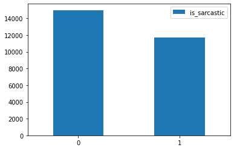

```python
import matplotlib.pyplot as plt
%matplotlib inline

df_sarcastic.plot(kind = 'bar')
plt.xticks(rotation = 0)
```

```python
sarcastic_headlines = data.loc[data['is_sarcastic'] == 1]
#undersample non sarcastic headline
non_sarcastic_headlines = data.loc[data['is_sarcastic'] == 0].sample(n = 11724, random_state = 25)
```

```python
from wordcloud import WordCloud, STOPWORDS, ImageColorGenerator
```

```python
text = ' '.join(review for review in sarcastic_headlines.headline)
print ('There are {} words in the combination of all review.'.format(len(text)))
```

```
There are 746098 words in the combination of all review.
```

**Word cloud of Sarcastic Headlines**

```
(-0.5, 399.5, 199.5, -0.5)
```

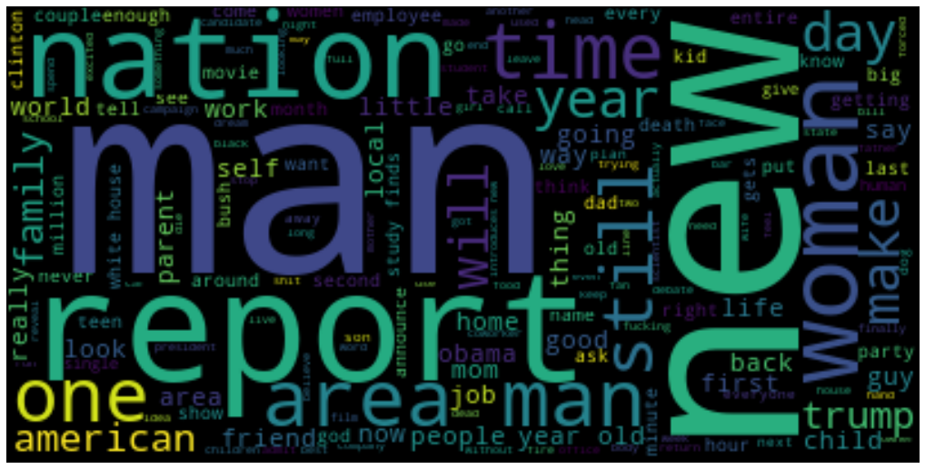

```python
stopwords = set(STOPWORDS)

# Generate a word cloud image
wordcloud = WordCloud(stopwords = stopwords, background_color = "black").generate(text)

# Display the generated image:
# the matplotlib way:
plt.figure(figsize = [18, 18])
plt.imshow(wordcloud, interpolation = 'bilinear')
plt.axis("off")
```

**Word cloud of Non Sarcastic Headlines**

```python
text_ns = ' '.join(review for review in non_sarcastic_headlines.headline)
print ('There are {} words in the combination of all review.'.format(len(text_ns)))
```

```
There are 708413 words in the combination of all review.
```

```
(-0.5, 399.5, 199.5, -0.5)
```

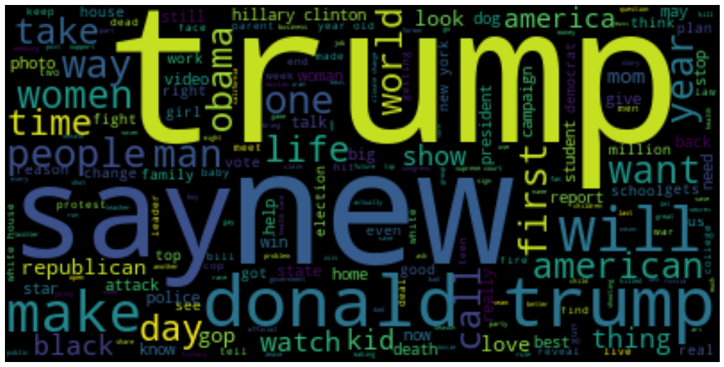

```python
stopwords = set(STOPWORDS)

# Generate a word cloud image
wordcloud = WordCloud(stopwords = stopwords, background_color = "black").generate(text_ns)

# Display the generated image:
plt.figure(figsize = [18, 18])
plt.imshow(wordcloud, interpolation = 'bilinear')
plt.axis("off")
```

**2.2. Retaining Relevant Columns**

- Dropping article_link from dataset and retaining other columns in the dataset

```python
data = pd.concat([sarcastic_headlines, non_sarcastic_headlines])
```

```python
data = data.drop(columns = 'article_link', axis = 1)
data.head()
```

|  | headline | is_sarcastic |
| --- | --- | --- |
| 2 | mom starting to fear son's web series closest ... | 1 |
| 3 | boehner just wants wife to listen, not come up... | 1 |
| 8 | top snake handler leaves sinking huckabee camp... | 1 |
| 15 | nuclear bomb detonates during rehearsal for 's... | 1 |
| 16 | cosby lawyer asks why accusers didn't come for... | 1 |

**2.3. Getting length of each sentence**

Different sentences are of varied length. Hence, padding the sequences using the max length

```python
contractions = {
"ain't": "am not / are not / is not / has not / have not",
"aren't": "are not / am not",
"can't": "cannot",
"can't've": "cannot have",
"'cause": "because",
"could've": "could have",
"couldn't": "could not",
"couldn't've": "could not have",
"didn't": "did not",
"doesn't": "does not",
"don't": "do not",
"hadn't": "had not",
"hadn't've": "had not have",
"hasn't": "has not",
"haven't": "have not",
"he'd": "he had / he would",
"he'd've": "he would have",
"he'll": "he shall / he will",
"he'll've": "he shall have / he will have",
"he's": "he has / he is",
"how'd": "how did",
"how'd'y": "how do you",
"how'll": "how will",
"how's": "how has / how is / how does",
"I'd": "I had / I would",
"I'd've": "I would have",
"I'll": "I shall / I will",
"I'll've": "I shall have / I will have",
"I'm": "I am",
"I've": "I have",
"isn't": "is not",
"it'd": "it had / it would",
"it'd've": "it would have",
"it'll": "it shall / it will",
"it'll've": "it shall have / it will have",
"it's": "it has / it is",
"let's": "let us",
"ma'am": "madam",
"mayn't": "may not",
"might've": "might have",
"mightn't": "might not",
"mightn't've": "might not have",
"must've": "must have",
"mustn't": "must not",
"mustn't've": "must not have",
"needn't": "need not",
"needn't've": "need not have",
"o'clock": "of the clock",
"oughtn't": "ought not",
"oughtn't've": "ought not have",
"shan't": "shall not",
"sha'n't": "shall not",
"shan't've": "shall not have",
"she'd": "she had / she would",
"she'd've": "she would have",
"she'll": "she shall / she will",
"she'll've": "she shall have / she will have",
"she's": "she has / she is",
"should've": "should have",
"shouldn't": "should not",
"shouldn't've": "should not have",
"so've": "so have",
"so's": "so as / so is",
"that'd": "that would / that had",
"that'd've": "that would have",
"that's": "that has / that is",
"there'd": "there had / there would",
"there'd've": "there would have",
"there's": "there has / there is",
"they'd": "they had / they would",
"they'd've": "they would have",
"they'll": "they shall / they will",
"they'll've": "they shall have / they will have",
"they're": "they are",
"they've": "they have",
"to've": "to have",
"wasn't": "was not",
"we'd": "we had / we would",
"we'd've": "we would have",
"we'll": "we will",
"we'll've": "we will have",
"we're": "we are",
"we've": "we have",
"weren't": "were not",
"what'll": "what shall / what will",
"what'll've": "what shall have / what will have",
"what're": "what are",
"what's": "what has / what is",
"what've": "what have",
"when's": "when has / when is",
"when've": "when have",
"where'd": "where did",
"where's": "where has / where is",
"where've": "where have",
"who'll": "who shall / who will",
"who'll've": "who shall have / who will have",
"who's": "who has / who is",
"who've": "who have",
"why's": "why has / why is",
"why've": "why have",
"will've": "will have",
"won't": "will not",
"won't've": "will not have",
"would've": "would have",
"wouldn't": "would not",
"wouldn't've": "would not have",
"y'all": "you all",
"y'all'd": "you all would",
"y'all'd've": "you all would have",
"y'all're": "you all are",
"y'all've": "you all have",
"you'd": "you had / you would",
"you'd've": "you would have",
"you'll": "you shall / you will",
"you'll've": "you shall have / you will have",
"you're": "you are",
"you've": "you have"
}
```

```python
def clean_text(text, remove_stopwords=True):
  # Convert words to lower case
  text = text.lower()
  if True:
    text = text.split()
    new_text = []
    for word in text:
      if word in contractions:
        new_text.append(contractions[word])
      else:
        new_text.append(word)
      text = " ".join(new_text)
      text = re.sub(r'https?:\/\/.*[\r\n]*', '', text, flags=re.MULTILINE)
      text = re.sub(r'\<a href', ' ', text)
      text = re.sub(r'&amp;', '', text)
      text = re.sub(r'[_"\-;%()|+&=*%.,!?:#$@\[\]/]', ' ', text)
      text = re.sub(r'<br />', ' ', text)
      text = re.sub(r'\'', ' ', text)
      if remove_stopwords:
        text = text.split()
        stops = set(stopwords.words("english"))
        text = [w for w in text if not w in stops]
        text = " ".join(text)
  return text
```

```python
import nltk
nltk.download('stopwords')

# Clean the headlines
import re
from nltk.corpus import stopwords
from pickle import dump, load

clean_balanced_headlines = []
for headline in data['headline']:
  clean_balanced_headlines.append(clean_text(headline, remove_stopwords = False))
print('Data is cleaned!')
```

```
Data is cleaned!
```

```python
data['cleaned_headline'] = clean_balanced_headlines
data.head()
```

|  | headline | is_sarcastic | cleaned_headline |
| --- | --- | --- | --- |
| 2 | mom starting to fear son's web series closest ... | 1 | mom starting to fear son s web series closest ... |
| 3 | boehner just wants wife to listen, not come up... | 1 | boehner just wants wife to listen not come up... |
| 8 | top snake handler leaves sinking huckabee camp... | 1 | top snake handler leaves sinking huckabee camp... |
| 15 | nuclear bomb detonates during rehearsal for 's... | 1 | nuclear bomb detonates during rehearsal for s... |
| 16 | cosby lawyer asks why accusers didn't come for... | 1 | cosby lawyer asks why accusers did not come fo... |

```python
data = data.drop('headline', axis = 1)
data.head()
```

|  | is_sarcastic | cleaned_headline |
| --- | --- | --- |
| 2 | 1 | mom starting to fear son s web series closest ... |
| 3 | 1 | boehner just wants wife to listen not come up... |
| 8 | 1 | top snake handler leaves sinking huckabee camp... |
| 15 | 1 | nuclear bomb detonates during rehearsal for s... |
| 16 | 1 | cosby lawyer asks why accusers did not come fo... |

```python
print (data['cleaned_headline'][7])
```

```
this ceo will send your kids to school  if you work for his company
```

```python
# Length of above headline
len(data['cleaned_headline'][7].split())
```

```
14
```

```python
max_length = max([len(headline.split()) for headline in data['cleaned_headline']])
print('Maximum Length: ', max_length)
```

```
Maximum Length:  39
```

**2.4. Defining Parameters for the model**

```python
max_features = 10000
maxlen = max_length
embedding_size = 200
```

**2.5. Getting Indices for words**

```python
# Applying Keras Tokenizer on headline column of the data
tokenizer = Tokenizer(num_words = max_features)
tokenizer.fit_on_texts(data['cleaned_headline'])
```

**2.6. Creating features and labels**

```python
X = tokenizer.texts_to_sequences(data['cleaned_headline'])
X = pad_sequences(X, maxlen = maxlen)
y = np.asarray(data['is_sarcastic'])

print("Number of Samples:", len(X))
print(X[0])
print("Number of Labels: ", len(y))
print(y[0])
```

```
Number of Samples: 23448
[   0    0    0    0    0    0    0    0    0    0    0    0    0    0
    0    0    0    0    0    0    0    0    0    0  119  773    1  869
  235    4 2316  623 4302  215   72   33   40    1 9633]
Number of Labels:  23448
1
```

**2.7. Getting Vocabulary size**

```python
vocab_size = len(tokenizer.word_index) + 1
print('Vocabulary Size: ', vocab_size)
```

```
Vocabulary Size:  24115
```

**2.8. Creating weight matrix using GloVe embeddings**

```python
# Get GloVe word embeddings
glove_file = project_path + "glove.6B.zip"
```

```python
#Extract Glove embedding zip file
from zipfile import ZipFile
with ZipFile(glove_file, 'r') as z:
  z.extractall()
```

```python
# Get Word Embeddings using Embedding file - glove.6B.200d.txt
EMBEDDING_FILE = './glove.6B.200d.txt'

embeddings = {}
for o in open(EMBEDDING_FILE):
    word = o.split(" ")[0]
    # print(word)
    embd = o.split(" ")[1:]
    embd = np.asarray(embd, dtype='float32')
    # print(embd)
    embeddings[word] = embd
```

```python
# Creating weight matrix for words in training documents
embedding_matrix = np.zeros((vocab_size, 200))

for word, i in tokenizer.word_index.items():
    embedding_vector = embeddings.get(word)
    if embedding_vector is not None:
        embedding_matrix[i] = embedding_vector

len(embeddings.values())
```

```
400000
```

**2.9. Defining and Compiling Bi-directional LSTM model**

```python
### create the model
model = Sequential()

### Embedding layer
model.add(Embedding(vocab_size, embedding_size, weights = [embedding_matrix]))

### Bidirectional LSTM layer
model.add(Bidirectional(LSTM(512, return_sequences = True)))

### dense
model.add(Dense(256, activation = 'relu'))

##dropout
model.add(Dropout(0.5, input_shape = (256,)))

##sigmoid
model.add(Dense(1, activation = 'sigmoid'))
model.compile(loss = 'binary_crossentropy', optimizer = 'adam', metrics = ['accuracy'])
model.summary()
```

```
Model: "sequential_1"
_________________________________________________________________
Layer (type)                 Output Shape              Param #
=================================================================
embedding_1 (Embedding)      (None, None, 200)         4823000
_________________________________________________________________
bidirectional (Bidirectional (None, None, 1024)        2920448
_________________________________________________________________
dense_1 (Dense)              (None, None, 256)         262400
_________________________________________________________________
dropout_1 (Dropout)          (None, None, 256)         0
_________________________________________________________________
dense_2 (Dense)              (None, None, 1)           257
=================================================================
Total params: 8,006,105
Trainable params: 8,006,105
Non-trainable params: 0
_________________________________________________________________
```

**2.10. Fitting the model and checking validation accuracy**

```python
# batch size is taken as 100 and validation_split is taken as 0.2
batch_size = 100
epochs = 5

history = model.fit(X, y, batch_size = batch_size, epochs = epochs, verbose = 1, validation_split = 0.2)
```

[output not shown]